# Project proposal

Jack, Luke, Dexter

```r
library(tidyverse)
library(broom)
```

## 1. Introduction

The data has been collected from Major League Baseball’s Statcast program. It contains pitcher data from 2021 to 2024, detailing the outcome of each pitch thrown. Each observation is the summary statistic of each pitcher in a specific year, where it demonstrates the outcomes of all pitches thrown. Each variable represents the outcome of a pitch, or event such as a pickoff attempt. Our research question is: “Is there a correlation between pitcher actions(Pitches, Pickoff Attempts, etc.) and pitcher success measured in wins and losses.”

## 2. Data

```r
getwd()
```

```
## [1] "/cloud/project/proposal"
```

```r
baseball <- read_csv("../data/pitching_data_2021-2024.csv")
glimpse(baseball)
```

```
## Rows: 411
## Columns: 116
## $ `last_name, first_name` <chr> "Wainwright, Adam", "Greinke, Zack", "Hill, Ri…
## $ player_id               <dbl> 425794, 425844, 448179, 450203, 452657, 453286…
## $ year                    <dbl> 2021, 2021, 2021, 2021, 2021, 2021, 2021, 2021…
## $ player_age              <dbl> 39, 37, 41, 37, 37, 36, 38, 34, 34, 33, 33, 34…
## $ p_game                  <dbl> 32, 30, 32, 33, 28, 30, 30, 28, 28, 28, 31, 30…
## $ p_formatted_ip          <dbl> 206.1, 171.0, 158.2, 185.2, 141.1, 179.1, 152.…
## $ pa                      <dbl> 828, 697, 661, 756, 627, 693, 671, 641, 690, 6…
## $ ab                      <dbl> 765, 652, 582, 669, 558, 644, 615, 588, 627, 6…
## $ hit                     <dbl> 168, 164, 137, 136, 159, 119, 177, 123, 166, 1…
## $ single                  <dbl> 111, 105, 83, 100, 101, 73, 106, 84, 112, 91, …
## $ double                  <dbl> 34, 29, 32, 17, 33, 21, 35, 20, 35, 35, 32, 35…
## $ triple                  <dbl> 2, 0, 1, 3, 0, 2, 6, 1, 2, 4, 2, 5, 2, 4, 4, 2…
## $ home_run                <dbl> 21, 30, 21, 16, 25, 23, 30, 18, 17, 26, 17, 28…
```

[output cut: 103 more lines]

## 3. Data analysis plan

Our plan is to understand what pitch combinations make a pitcher better or worse. This can be done by looking at pitch combinations and batter success against a pitcher. Visualizing this will present an image of success. We will also look at time trends to see how pitchers change their pitch combinations as they age in order to stay successful. The visualizations below demonstrate that there is differentiation among the data in terms of strikeouts and that there is a probable correlation between innings pitched and Earned Run Average-the average number of runs allowed over 9 innings-(ERA), where as more innings are pitched, ERA decreases. Our visualizations can look at sucess at different ages and look to see how throwing different combinations of pitches can be successful. We can also look at how success differs between wins and ERA. Therefore we can understand which pitchers may be winning because they have a powerful offense on their team, wehreas some may be failing eventhough they have a good ERA because their offense does not generate enough runs.

```r
library(ggplot2)
#Summary Statistics
summary(baseball)
```

```
##  last_name, first_name   player_id           year        player_age
##  Length:411            Min.   :425794   Min.   :2021   Min.   :22.00
##  Class :character      1st Qu.:592332   1st Qu.:2022   1st Qu.:26.00
##  Mode  :character      Median :622072   Median :2023   Median :28.00
##                        Mean   :611244   Mean   :2023   Mean   :28.95
##                        3rd Qu.:663840   3rd Qu.:2024   3rd Qu.:31.00
##                        Max.   :694973   Max.   :2024   Max.   :43.00
##      p_game      p_formatted_ip        pa              ab
##  Min.   :21.00   Min.   :114.0   Min.   :502.0   Min.   :449.0
##  1st Qu.:27.00   1st Qu.:137.0   1st Qu.:584.5   1st Qu.:524.5
##  Median :30.00   Median :157.2   Median :665.0   Median :604.0
##  Mean   :29.31   Mean   :158.4   Mean   :662.3   Mean   :602.4
##  3rd Qu.:32.00   3rd Qu.:178.2   3rd Qu.:740.5   3rd Qu.:674.5
##  Max.   :42.00   Max.   :228.2   Max.   :886.0   Max.   :820.0
##       hit            single           double          triple
##  Min.   : 84.0   Min.   : 45.00   Min.   :14.00   Min.   : 0.000
##  1st Qu.:127.0   1st Qu.: 81.50   1st Qu.:24.00   1st Qu.: 1.000
##  Median :146.0   Median : 94.00   Median :29.00   Median : 2.000
##  Mean   :146.3   Mean   : 94.39   Mean   :29.14   Mean   : 2.394
##  3rd Qu.:164.5   3rd Qu.:107.50   3rd Qu.:34.00   3rd Qu.: 3.000
##  Max.   :226.0   Max.   :152.00   Max.   :54.00   Max.   :11.000
##     home_run       strikeout          walk         k_percent
##  Min.   : 6.00   Min.   : 73.0   Min.   :18.00   Min.   :12.50
##  1st Qu.:16.00   1st Qu.:123.0   1st Qu.:39.00   1st Qu.:19.50
##  Median :20.00   Median :149.0   Median :47.00   Median :22.70
##  Mean   :20.39   Mean   :152.1   Mean   :47.84   Mean   :22.91
##  3rd Qu.:24.00   3rd Qu.:177.0   3rd Qu.:56.00   3rd Qu.:25.90
##  Max.   :44.00   Max.   :281.0   Max.   :99.00   Max.   :38.30
##    bb_percent      batting_avg      slg_percent     on_base_percent
##  Min.   : 2.500   Min.   :0.1650   Min.   :0.2640   Min.   :0.2270
##  1st Qu.: 6.000   1st Qu.:0.2250   1st Qu.:0.3650   1st Qu.:0.2845
##  Median : 7.100   Median :0.2430   Median :0.4020   Median :0.3030
##  Mean   : 7.277   Mean   :0.2433   Mean   :0.4019   Mean   :0.3045
##  3rd Qu.: 8.500   3rd Qu.:0.2620   3rd Qu.:0.4350   3rd Qu.:0.3220
##  Max.   :15.400   Max.   :0.3210   Max.   :0.5590   Max.   :0.3810
##  on_base_plus_slg isolated_power       babip         p_earned_run
##  Min.   :0.4970   Min.   :0.0720   Min.   :0.2210   Min.   : 29.00
##  1st Qu.:0.6555   1st Qu.:0.1360   1st Qu.:0.2730   1st Qu.: 58.00
##  Median :0.7080   Median :0.1580   Median :0.2900   Median : 68.00
##  Mean   :0.7064   Mean   :0.1586   Mean   :0.2903   Mean   : 68.48
```

[output cut: 155 more lines]

```
##  Max.   :0           Max.   :14.000     Max.   :0.3850   Max.   :0.3810
##  sweet_spot_percent barrel_batted_rate hard_hit_percent avg_best_speed
##  Min.   :21.40      Min.   : 3.100     Min.   :28.20    Min.   :71.90
##  1st Qu.:32.20      1st Qu.: 6.800     1st Qu.:36.10    1st Qu.:76.73
##  Median :34.10      Median : 7.800     Median :38.80    Median :77.90
##  Mean   :34.01      Mean   : 7.855     Mean   :38.74    Mean   :77.79
##  3rd Qu.:36.10      3rd Qu.: 9.000     3rd Qu.:41.35    3rd Qu.:78.96
##  Max.   :41.00      Max.   :13.900     Max.   :48.60    Max.   :82.02
##  avg_hyper_speed whiff_percent   swing_percent
##  Min.   :92.35   Min.   :16.40   Min.   :41.60
##  1st Qu.:93.66   1st Qu.:22.15   1st Qu.:46.40
##  Median :94.08   Median :24.80   Median :48.20
##  Mean   :94.05   Mean   :25.06   Mean   :48.29
##  3rd Qu.:94.42   3rd Qu.:27.60   3rd Qu.:49.95
##  Max.   :95.64   Max.   :38.60   Max.   :55.90
```

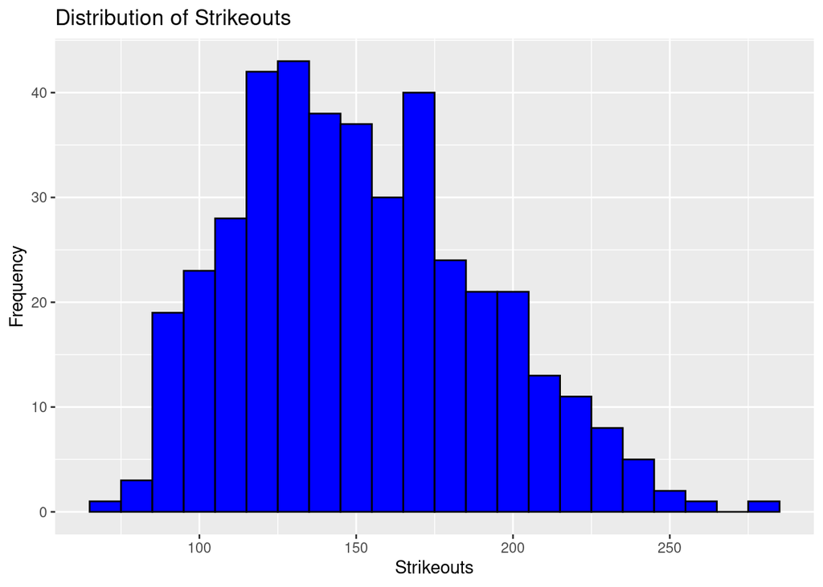

```r
#Histogram of strikeouts
ggplot(baseball, aes(x = strikeout)) +
  geom_histogram(binwidth = 10, fill = "blue", color = "black") +
  labs(title = "Distribution of Strikeouts", x = "Strikeouts", y = "Frequency")
```

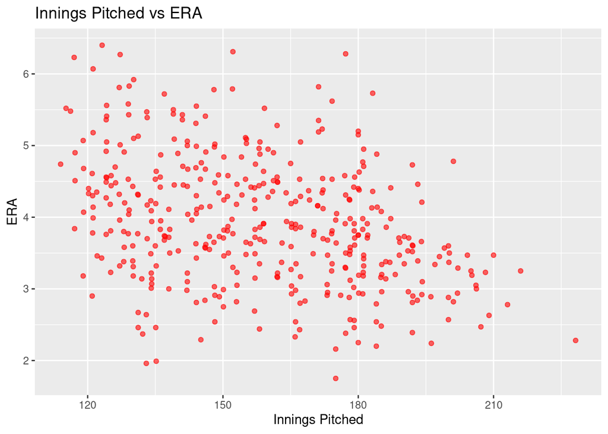

```r
#ERA vs Innings pitched
ggplot(baseball, aes(x = p_formatted_ip, y = p_era)) +
  geom_point(color = "red", alpha = 0.6) +
  labs(title = "Innings Pitched vs ERA", x = "Innings Pitched", y = "ERA")
```

## 4. Data Ethics Review

The data ethics review section will be introduced in a separate class and is not part of the original proposal deadline.